🌿

# 2025 台灣青蔥價格專題報告

Taiwan Green Onion Price Analysis — 114 年全年資料

📅 資料區間：2025/01/01 – 2025/12/31 🗂 資料筆數：2,928 筆 🏪 涵蓋市場：台北二、台中市、高雄市 🌱 品種：SE1 – SE6 青蔥六類

## 📋 目錄

1. 專題概述
2. 所使用的 AI 工具
3. 爬蟲設計與流程
4. 遇到的困難與解法
5. 資料量與欄位說明
6. 三種蔥的特色比較
7. 視覺化圖表說明
8. 主要發現
9. 參考來源

Section 01

## 專題概述

2,928

總爬取筆數

6

青蔥品種（SE1–SE6）

3

批發市場

18

HTTP 請求次數

365

涵蓋天數

研究問題聚焦三個面向：

- 不同品種與地區的價格結構有何差異？
- 日蔥為何普遍偏貴、且幾乎只見於台北市場？
- 2025 年蔥價高點為何集中於夏末（7–9 月），以及 11 月底為何出現年度峰值？

Section 02

## 所使用的 AI 工具

🤖

### Claude（Anthropic）— claude-sonnet-4-6

本專題從零開始，全程透過 **Claude Code（CLI 互動式 AI 助手）**完成，涵蓋以下任務： 網站結構分析與 ASP.NET ViewState 破解策略規劃、Python 爬蟲程式撰寫（`scrape_greenonion.py`）、 Matplotlib 視覺化圖表設計（`plot_greenonion.py`）、網路資料搜尋整合（品種特性、颱風事件）、 以及本報告頁面（`REPORT.html`）的撰寫與排版。 AI 不僅作為程式碼生成工具，也扮演了資料解讀與新聞事件交叉比對的角色。

🐍

### Python 爬蟲

requests、BeautifulSoup、xlrd 套件組合，模擬表單 POST 並下載 Excel 格式資料

📊

### Matplotlib + Pandas

資料清洗、日期轉換（民國曆→西元曆）、7 日滾動均線、Heatmap 可視化

🌐

### WebSearch（Claude 工具）

搜尋農業知識入口網、上下游新聞、自由電子報等，整合品種與市場背景知識

Section 03

## 爬蟲設計與流程

目標網站為農業部農產品批發市場交易行情系統（AMIS）蔬菜區， 使用 ASP.NET WebForms 技術，每次查詢需攜帶動態產生的 `__VIEWSTATE`、`__VIEWSTATEGENERATOR`、`__EVENTVALIDATION` 三個隱藏欄位。

### 流程圖解

1️⃣

### 取得 ViewState

先以 GET 請求抓取頁面，解析三個 ASP.NET 隱藏欄位作為後續 POST 的憑證

2️⃣

### 發現市場代碼

存取市場選擇器頁面（`VegMarketSelector.aspx`），取得台北二=104、台中市=400、高雄市=800

3️⃣

### 觸發 Excel 下載

改以「下載Excel」按鈕的 POST payload，直接取得含有日期欄位的 XLS 檔，繞過 HTML 無日期的問題

4️⃣

### 批次爬取 18 組合

6 品種 × 3 市場 = 18 個請求，每次間隔 1 秒避免對伺服器造成壓力

5️⃣

### 解析 XLS

以 xlrd 讀取二進位 XLS，跳過前四列說明文字，從標題列後擷取每日交易記錄

6️⃣

### 輸出 CSV

整合所有 18 組合的資料，標準化欄位名稱，輸出 UTF-8 BOM 的 `greenonion.csv`

### 爬蟲核心邏輯（Python）

# 1. 每次 POST 前重新取得 ViewState（ASP.NET 每次都會更新） def get_viewstate(session): r = session.get(BASE_URL) soup = BeautifulSoup(r.text, "html.parser") return {field: soup.find("input", {"name": field})["value"] for field in ["__VIEWSTATE", "__VIEWSTATEGENERATOR", "__EVENTVALIDATION"]} # 2. 觸發 Excel 下載（而非 HTML 查詢） payload["ctl00$contentPlaceHolder$btnXls"] = "下載Excel" r = session.post(BASE_URL, data=payload) # 3. 以 xlrd 解析取得日期欄位 wb = xlrd.open_workbook(file_contents=r.content) # XLS 第5列起為資料，欄位：日期、市場、產品、上價、中價、下價、平均價、交易量

Section 04

## 遇到的困難與解法

1

### HTML 結果頁面沒有日期欄位

AMIS 查詢結果的 HTML 表格只有「市場、產品、上價、中價、下價、平均價、交易量」，不含日期。若按月查詢，無法判斷每筆資料對應哪一天。

**解法：**改觸發頁面上的「下載 Excel」功能（同一 POST，將 submit 按鈕改為 `btnXls`），下載的 XLS 檔案第一欄即為完整日期，問題徹底解決。同時，一次查詢全年（1/1–12/31）即可，原本擔心的月份分批問題也不復存在。

2

### ASP.NET ViewState 動態更新

ASP.NET WebForms 的 `__VIEWSTATE` 等隱藏欄位每次頁面載入都會重新產生，若重複使用舊的 token 會導致查詢失敗。

**解法：**設計 `get_viewstate()` 函式，每次 POST 前都先 GET 一次頁面重新取得最新的三個 token，確保每次請求都帶有有效憑證。

3

### 市場代碼未公開標示

主頁面的表單使用 dialog 視窗讓使用者選擇市場，市場代碼存在隱藏欄位，無法直接從主頁面 HTML 讀取三大市場的代碼。

**解法：**直接存取市場選擇器子頁面（`VegMarketSelector.aspx`），從其中的純文字清單讀取完整的市場代碼對照表：台北二=104、台中市=400、高雄市=800。

4

### 部分市場 × 品種組合資料稀少

**解法：**這並非爬蟲失敗，而是真實市場現象的反映（日蔥產地集中北部、南部市場幾乎不交易）。在視覺化時標示「無資料」，並在分析報告中說明此現象的背景原因。

Section 05

## 爬取資料量與欄位說明

最終輸出檔案：`greenonion.csv`（UTF-8 BOM 編碼，Excel 可直接開啟）

### 欄位說明

| 欄位名稱 | 說明 | 範例 |
| --- | --- | --- |
| 日期 | 民國曆格式（AMIS 原始格式） | 114/08/24 |
| 市場代碼 | AMIS 批發市場代碼 | 104 |
| 市場 | 市場中文名稱 | 台北二 |
| 產品代碼 | AMIS 品種代碼 | SE1 |
| 產品 | 品種完整名稱 | SE1 青蔥 日蔥 |
| 上價 | 當日最高成交價（元/公斤） | 380.0 |
| 中價 | 當日中間成交價（元/公斤） | 110.4 |
| 下價 | 當日最低成交價（元/公斤） | 100.0 |
| 平均價(元/公斤) | 當日加權平均成交價 | 162.2 |
| 交易量(公斤) | 當日總交易重量（公斤） | 135.0 |

### 各品種 × 市場資料筆數

| 品種 | 台北二 | 台中市 | 高雄市 | 小計 |
| --- | --- | --- | --- | --- |
| SE1 日蔥 | 290 | 13 | 1（無實質資料） | 304 |
| SE2 北蔥 | 193 | 211 | 58 | 462 |
| SE3 大蔥 | 123 | 54 | 59 | 236 |
| SE4 珠蔥 | 71 | 93 | 40 | 204 |
| SE5 紅蔥頭 | 292 | 240 | 303 | 835 |
| SE6 粉蔥 | 292 | 292 | 303 | 887 |
| 合計 | 1,261 | 903 | 764 | 2,928 |

Section 06

## 三種蔥的特色比較

本專題重點分析的三個品種在外觀、口感、產地與市場定位上各有顯著差異：

### 🌿 日蔥（四季蔥）

SE1 ／ 三星蔥即屬此類

蔥白最長（≥20cm） 葉肉厚柔軟 纖維細嫩 辛辣溫和

又名「日本蔥」「九條蔥」「大廣蔥」，是台灣市場最受青睞的品種。全年可種，約 3 個月採收。**耐熱性差**，適合北部冷涼氣候，主要產地為宜蘭三星鄉（得益於雪山山脈水源、頁岩地質、日夜溫差大）。

⚠️ 因氣候變遷，夏季高溫導致產量可能僅剩正常的 1/3，是價格最不穩定的品種。

### 💙 粉蔥（溪湖蔥）

SE6 ／ 全台產量最大

蔥白中等 甜度高 香味足 日常主流

推測為四季蔥的地方選系，主要產地在**彰化溪湖、雲林**。外觀與日蔥相似但蔥白略短，口感與日蔥幾無差異。是全台產量最大的蔥，占市場供給約八成，盛產期 11月–5月。

### 🔴 珠蔥（大頭蔥）

SE4 ／ 紅蔥頭地上部

植株最小 鱗莖肥大 不辛辣 香味濃郁

與日蔥、粉蔥截然不同的品種——實為**紅蔥頭的地上嫩莖**。蔥葉細長，根部鱗莖肥大，非常容易辨認（俗稱「大頭蔥」）。味道溫和不辣，但香味特別濃郁。

最適合爆香與製作油蔥酥，盛產期為農曆年前後。是台灣傳統料理的靈魂香料。

### 為什麼日蔥價格偏高，且幾乎只在台北？

- 🌡️

  **氣候限制供給端**：日蔥不耐熱，全台能穩定種植的地區主要只有宜蘭、桃園等北部冷涼地帶，南部高溫潮濕環境幾乎無法栽培，供給量天生受限。
- 🏪

  **批發通路集中台北二**：宜蘭三星蔥等日蔥的主要批發流向是台北第二果菜市場（代碼 104），南部市場取得不易，需求相應低落，形成台北獨大的市場結構。
- 💎

  **品質溢價**：蔥白長、纖維細嫩，是高端餐廳、日式料理、涮涮鍋的首選食材，消費者願意支付相對粉蔥 2 倍以上的價格。
- 📦

  **量少而精**：彰化、雲林的大規模蔥區以粉蔥為主，日蔥因技術門檻高、適種地狹窄，量始終無法與粉蔥競爭，稀缺性推高均價。

Section 07

## 視覺化圖表說明

### 圖一：品種 × 市場趨勢矩陣（3×3 格）

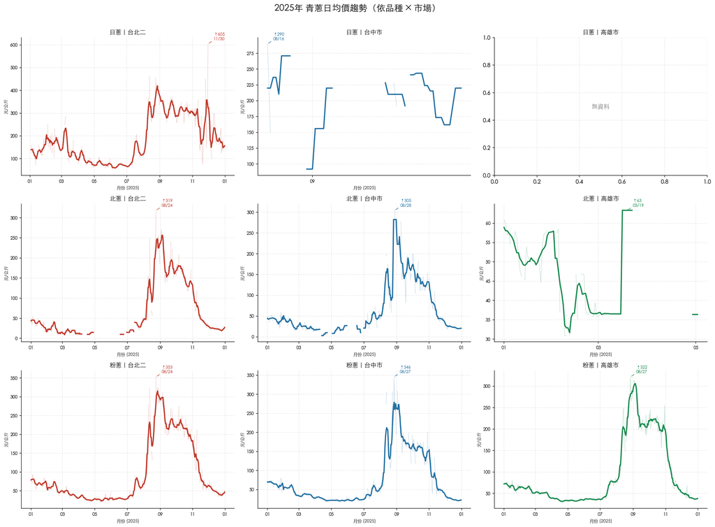

### 圖二：三地蔥價比較（7 日均線疊圖）

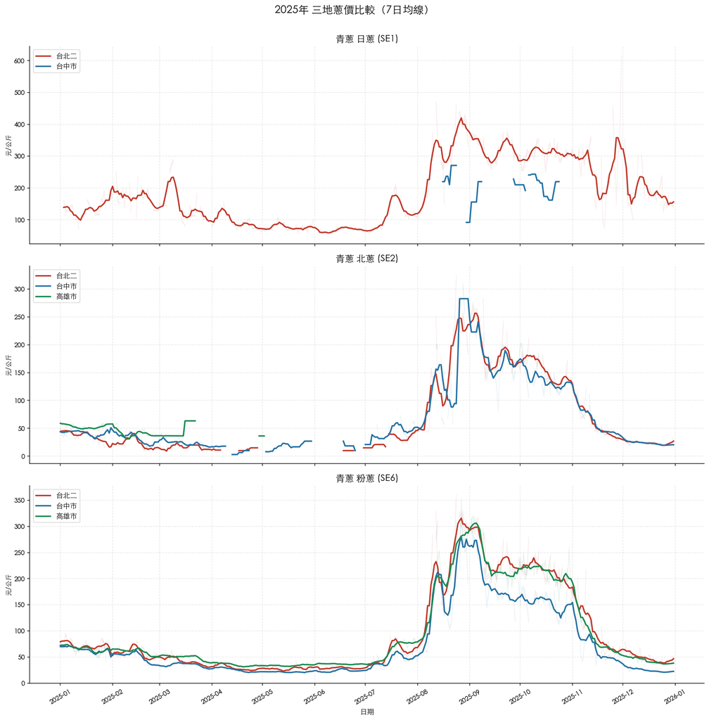

### 圖三：月均價 Heatmap

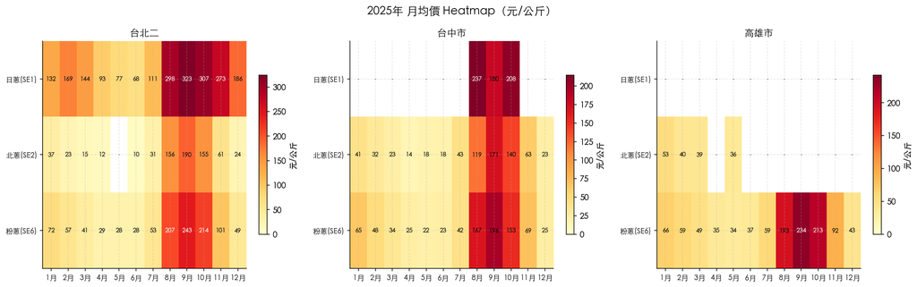

Section 08

## 主要發現

### 🏆 2025 年各品種價格峰值

| 品種 | 峰值（元/公斤） | 日期 | 市場 | 推測原因 |
| --- | --- | --- | --- | --- |
| 日蔥 SE1 | 605.0 | 2025-11-30 | 台北二 | 11月底日蔥供給結構性短缺（疑似晚颱或初冬寒害） |
| 粉蔥 SE6 | 353.4 | 2025-08-24 | 台北二 | 颱風楊柳 + 連續豪雨直接打壞彰化、雲林產區 |
| 北蔥 SE2 | 318.7 | 2025-08-24 | 台北二 | 同上，與粉蔥同日達峰，颱風共振效應 |

### 📌 六大結論

- 🌡️

  **粉蔥是最具代表性的「全國性蔥」**：三地資料最完整（各約 292–303 筆），走勢高度一致，年均價介於 72–94 元之間，是觀察全國蔥市行情最佳指標品種。
- 💰

  **日蔥年均價是粉蔥的 2 倍**：台北二日蔥年均 182.7 元，粉蔥年均 94.2 元，差距源自品質溢價與供給稀缺，且不受颱風以外因素影響時，日蔥價格仍明顯高於其他品種。
- 📅

  **冬季（11–12月）是蔥農的賭注時刻**：颱風過後，部分缺貨預期持續拉高蔥價至 10–11月；但若風調雨順，冬季粉蔥大量上市後價格往往重跌，日蔥 11月底 605 元峰值是少見的冬季特殊事件，可能與產地特定寒害有關。

Section 09

## 參考來源

- 1[農業部農產品批發市場交易行情系統（AMIS）— 蔬菜產品日交易行情](https://amis.afa.gov.tw/veg/VegProdDayTransInfo.aspx)
- 2[四季蔥粉蔥北蔥，你吃到的是哪種蔥？三星蔥白為何特別長？｜上下游新聞](https://www.newsmarket.com.tw/blog/116797/)
- 3[一把青蔥的賭局「以冬養工、以夏搏命」，青蔥產業脆弱結構｜上下游新聞](https://www.newsmarket.com.tw/blog/236577/)
- 4[日蔥、粉蔥、北蔥差在哪？原來這種吃起來最辛辣！｜自由電子報](https://food.ltn.com.tw/article/59)
- 5[不是只有三星蔥好吃！台灣蔥 5 大品種你認得嗎？｜自由電子報](https://food.ltn.com.tw/article/1701)
- 6[台灣栽培青蔥品種 — 農業知識入口網](https://kmweb.moa.gov.tw/subject/subject.php?id=23356)
- 7[豪雨、颱風導致菜價上漲，台北傳統市場 1 把蔥 380 元｜公視新聞網](https://news.pts.org.tw/article/765375)
- 8[颱風進逼菜價漲，青蔥每公斤衝破 300 元｜聯合新聞網](https://udn.com/news/story/7266/8327654)
- 9[讓三星蔥不怕高溫，耐熱青蔥「蘭陽 5 號」取得品種權｜農傳媒](https://www.agriharvest.tw/archives/57749/)
- 10[青蔥台農選 1 號，夏季也能穩定生產｜農傳媒](https://www.agriharvest.tw/archives/124920)
- 11[宜蘭的綠色獻禮，三星蔥｜農業知識入口網](https://kmweb.moa.gov.tw/theme_data.php?theme=news&sub_theme=quality_farmer&id=51846)